# Practical Machine Learning - Project

Corneliu Dicusar

Sunday, September 21, 2014

## Summary:

The aim of the project is to implement a machine learning algorithm for the “Weight Lifting Exercise Dataset” (http://groupware.les.inf.puc-rio.br/har). The model will try to predict the of the “classe” variable.

## Data description

The provided data sets has 160 columns with various recordings related to the “Weight Lifting Exercise” experiment. These variables describe a range of recordings, most of them of a discreent nature. However there are a number of columns which have either NA or blank values for most of the records in the dataset, which can adversely impact the analisys. The class of a record is given by the value in the column “classe”, which can have the following options: “A”, “B”,“C”,“D”,“E”.

## Reading and cleaning data

Both the provided training and testing sets have been downloaded locally and loaded in

```r
 trainingdt <- read.csv("pml-training.csv", header = TRUE, stringsAsFactors = FALSE,  na.strings=c("NA","NaN", ""))
 testingdt <- read.csv("pml-testing.csv", header = TRUE, stringsAsFactors = FALSE, na.strings=c("NA","NaN", ""))
```

```r
nonNA <-colSums(is.na(trainingdt))

tempList = character(0)
        for (i in 1:ncol(trainingdt)){
                       if(nonNA[i] > 0.9 * nrow(trainingdt))
                       {
                               tempList<-c(tempList, colnames(trainingdt)[i])
                       }
                }
        tempList<- c(tempList, "user_name", "new_window","cvtd_timestamp","X","raw_timestamp_part_1","raw_timestamp_part_2")
        trainingdt<- trainingdt[,!(names(trainingdt) %in% tempList)]
```

As can be seen above, there are a number of columns which have been eliminated from the analisys, as they are related to the specific instance of the record, and are not relevant to the model: “user_name”, “new_window”,“cvtd_timestamp”,“X”,“raw_timestamp_part_1”,“raw_timestamp_part_2”

## Building the model

The training set is split into a training and a testing pool of case with the proportion 80/20. This training subset will be used for cross-validation.

```r
        inTrain <- createDataPartition (y=trainingdt$classe, p=0.8, list=FALSE)
        training2 <- trainingdt[inTrain,]
        testing2 <- trainingdt[-inTrain,]
```

## Chosing the model

The first choice machine learning algorithm was LDA (Linear Discriminant Analysis) which attempts to express one dependent variable as a linear combination of other features or measurements

```r
modlda <- train(as.factor(classe)~., data = training2, method = "lda")
```

```r
plda <- predict(modlda, testing2)
```

The next choice was the qda (Quadratic Discriminant Analysis ) algorithm.

```r
modqda <- train(as.factor(classe)~., data = training2, method = "qda")

pqda <- predict(modqda, testing2)
```

This provided an accuracy of aproximately 90%, which is an acceptable level. A graphic representation of the performance can be seen in the plot below:

```r
cfm <- confusionMatrix(pqda,testing2$classe)
cfm
```

```
## Confusion Matrix and Statistics
##
##           Reference
## Prediction    A    B    C    D    E
##          A 1035   38    0    0    0
##          B   42  632   41    1   17
##          C   15   82  637  102   27
##          D   21    1    3  534   19
##          E    3    6    3    6  658
##
## Overall Statistics
##
##                Accuracy : 0.891
##                  95% CI : (0.881, 0.901)
##     No Information Rate : 0.284
##     P-Value [Acc > NIR] : <2e-16
##
##                   Kappa : 0.863
##  Mcnemar's Test P-Value : <2e-16
##
## Statistics by Class:
##
##                      Class: A Class: B Class: C Class: D Class: E
## Sensitivity             0.927    0.833    0.931    0.830    0.913
## Specificity             0.986    0.968    0.930    0.987    0.994
## Pos Pred Value          0.965    0.862    0.738    0.924    0.973
## Neg Pred Value          0.972    0.960    0.985    0.967    0.981
## Prevalence              0.284    0.193    0.174    0.164    0.184
## Detection Rate          0.264    0.161    0.162    0.136    0.168
## Detection Prevalence    0.274    0.187    0.220    0.147    0.172
## Balanced Accuracy       0.957    0.900    0.931    0.909    0.953
```

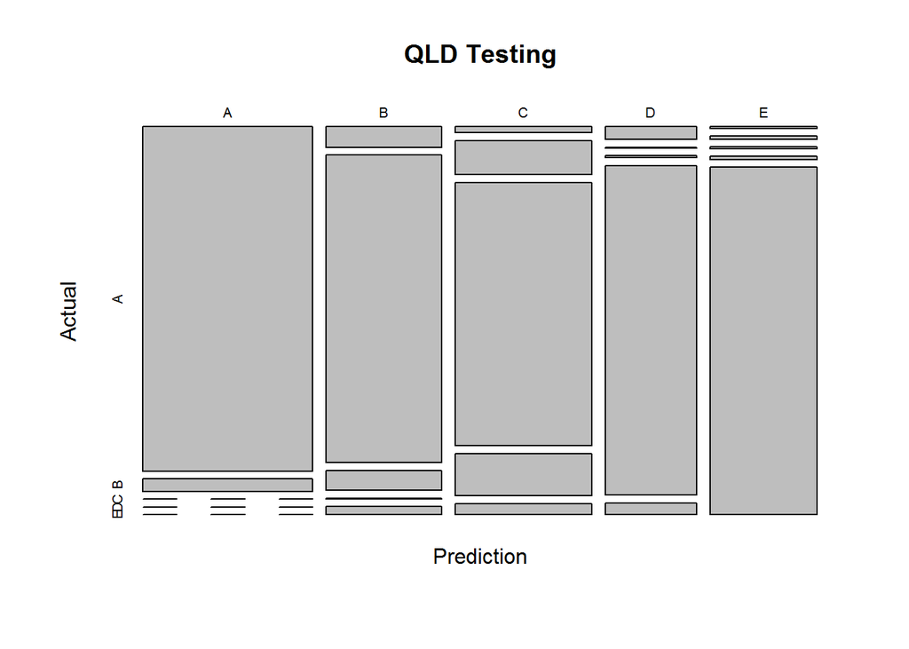

```r
plot(cfm$table, main="QLD Testing", ylab = "Actual")
```

## Estimating the test set

```r
        testingdt<- testingdt[,!(names(testingdt) %in% tempList)]
        testingdt[complete.cases(testingdt),]
```

```r
        predict(modlda, testingdt)
```

```
##  [1] B A B A A E D D A A D A E A B A A B B B
## Levels: A B C D E
```